# Session 5

## Question 2 Solution (6)

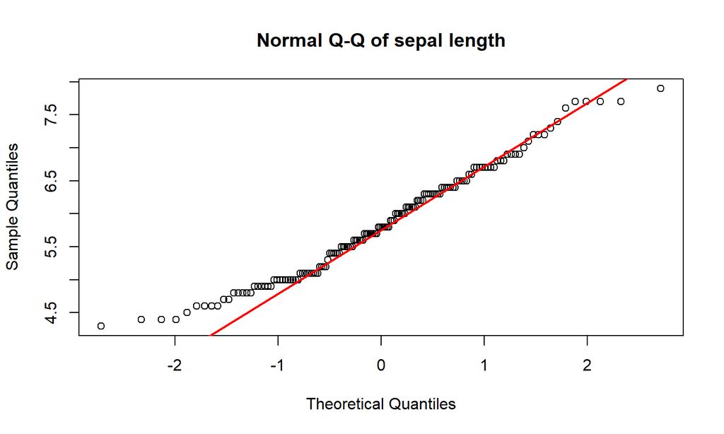

```r
qqnorm(iris$sepal_length, main="Normal Q-Q of sepal length")
qqline(iris$sepal_length, col = "red", lwd = 2)
```

## Question 2 Solution (7)

```r
# See if data transformation can solve the problem
iris$log_sl <- log(iris$sepal_length)
iris$sqrt_sl <- sqrt(iris$sepal_length)
```

## Question 2 Solution (8)

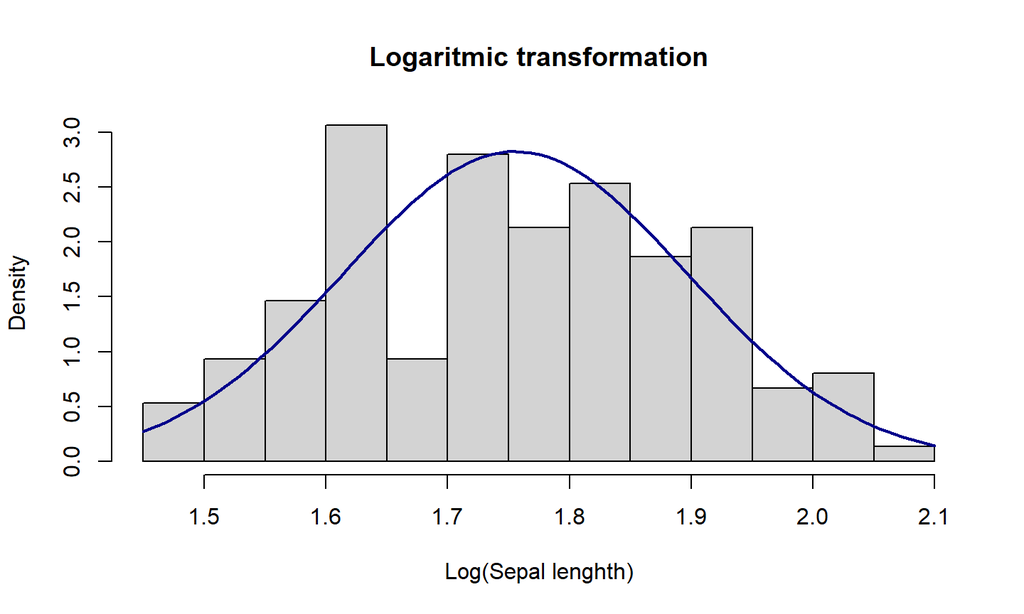

## Question 2 Solution (9)

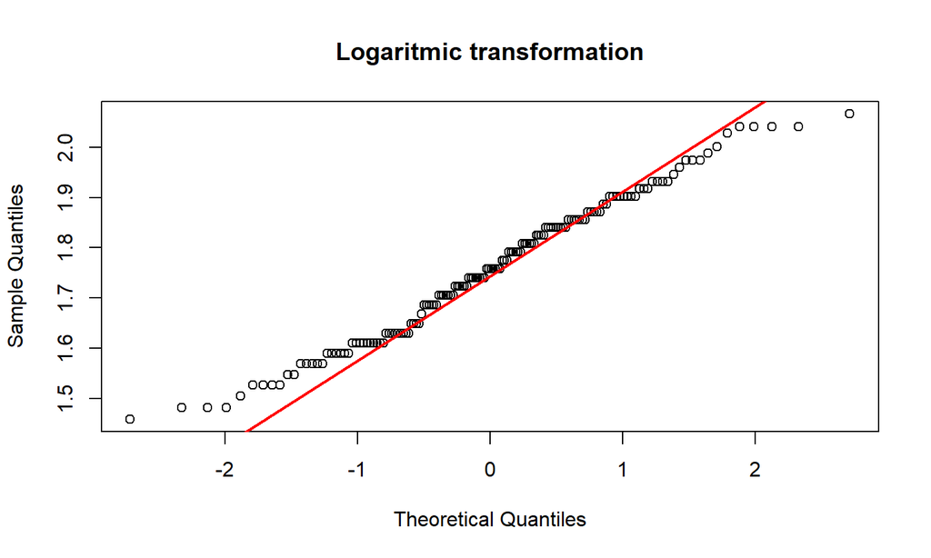

```r
qqnorm(iris$log_sl, main="Logaritmic transformation")
qqline(iris$log_sl, col = "red", lwd = 2)
```

## Question 2 Solution (10)

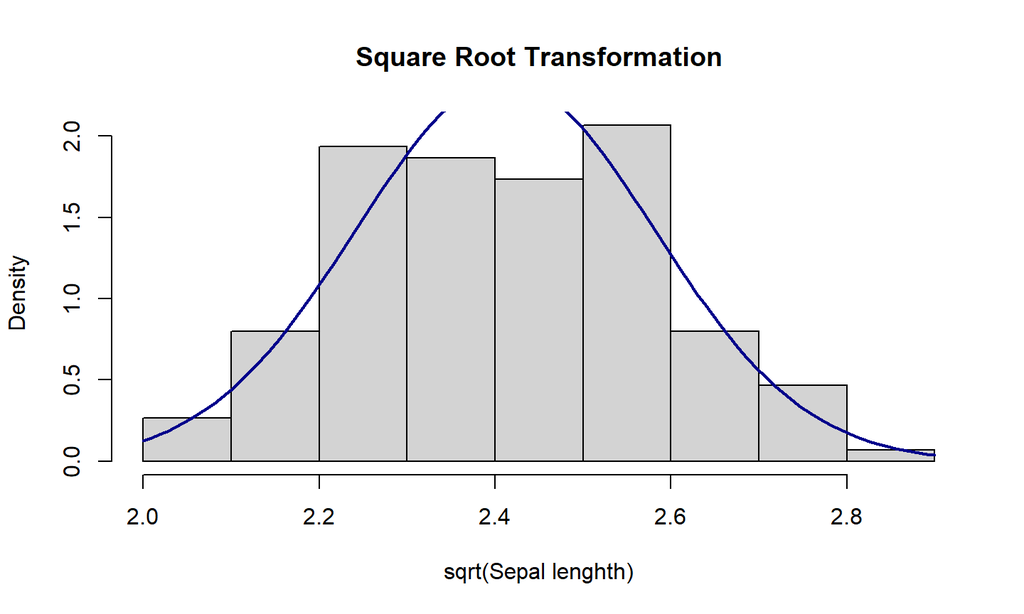

## Question 2 Solution (11)

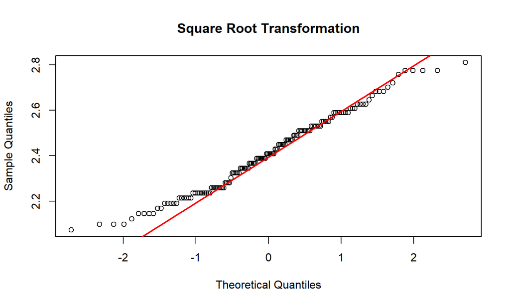

```r
qqnorm(iris$sqrt_sl, main="Square Root Transformation")
qqline(iris$sqrt_sl, col = "red", lwd = 2)
```

## Question 2 Solution (12)

```r
# Statistical test for normality (Shapiro-Wilk)
# Not recommended, because it is too strict
shapiro.test(iris$sepal_length)
```

```
##
##  Shapiro-Wilk normality test
##
## data:  iris$sepal_length
## W = 0.97609, p-value = 0.01018
```

```r
shapiro.test(iris$log_sl)
shapiro.test(iris$sqrt_sl)
```

[output not shown]

## Question 2 Solution (13)

```r
# We can check if homoscedasticity holds
library(car)

# No strong evidence for normal distribution --> Levene's test has better performance
leveneTest(sepal_length ~ Species, data = iris)
```

```
## Levene's Test for Homogeneity of Variance (center = median)
##        Df F value   Pr(>F)
## group   2  6.3527 0.002259 **
##       147
## ---
## Signif. codes:  0 '***' 0.001 '**' 0.01 '*' 0.05 '.' 0.1 ' ' 1
```

## Question 2 Solution (14)

```r
# Let's consider all assumptions are holding...
# Compute the ANOVA
res.aov <- aov(sepal_length ~ Species, data = iris)
summary(res.aov)
```

```
##              Df Sum Sq Mean Sq F value Pr(>F)
## Species       2  63.21  31.606   119.3 <2e-16 ***
## Residuals   147  38.96   0.265
## ---
## Signif. codes:  0 '***' 0.001 '**' 0.01 '*' 0.05 '.' 0.1 ' ' 1
```

## Question 2 Solution (15)

```r
# Post-hoc testing to check between samples
# Tuckey post-hoc test
TukeyHSD(res.aov)
```

```
##   Tukey multiple comparisons of means
##     95% family-wise confidence level
##
## Fit: aov(formula = sepal_length ~ Species, data = iris)
##
## $Species
##                       diff       lwr       upr p adj
## versicolor-setosa    0.930 0.6862273 1.1737727     0
## virginica-setosa     1.582 1.3382273 1.8257727     0
## virginica-versicolor 0.652 0.4082273 0.8957727     0
```

## Question 3

```r
data(meerdaal, package = "edcpR")
```

We have vegetation records in Meerdaal forest from 50 years ago. We know the exact location of the 13 plots and sample them again in 2018.

**Research question**: Is there a difference in species richness between old and recent sampling of forest fragments in Meerdaal forest?

## Question 3 Solution (1)

```r
data(meerdaal, package = "edcpR")
head(meerdaal)
```

```
##   Plot Old Recent
## 1    1   8      4
## 2    2   4      3
## 3    3  16     15
## 4    4  12     12
## 5    5  10     11
## 6    6  15      8
```

```r
colnames(meerdaal) <- c("Plot", "Old", "Recent")

# Difference in a quantitative variable between 2 paired samples
# Sample size = 13
# Too small for a parametric test --> non-parametric test
# Assumption: independent samples --> false, it is resampling of the same plots!
```

## Question 3 Solution (2)

```r
# Wilcoxon signed rank test
wilcox.test(meerdaal$Old, meerdaal$Recent, paired = TRUE)
```

```
##
##  Wilcoxon signed rank test with continuity correction
##
## data:  meerdaal$Old and meerdaal$Recent
## V = 63.5, p-value = 0.007203
## alternative hypothesis: true location shift is not equal to 0
```

## Question 4

```r
data(kembel_sp, package ="edcpR")
```

We measured the abundance of species in percent cover of different plant species in 20x20m quadrats in grasslands in plots in two habitat types in Alberta.

**Research question**: Is there a difference in total species richness between two grassland types?

## Question 4 Solution (1)

```r
# We are comparing gamma diversity!
# If we want to compare the mean diversity per plot (alfa diversity, use t-test)
# Chao estimators of two groups with t-test (see Session 3: Diversity)

library(dplyr)
# Extract plots of mixed grasslands
mixed <- kembel_sp %>% filter(grepl("mix", plot)) %>% select(-plot)

# Extract plots with fescue grass
fes <- kembel_sp %>% filter(grepl("fes", plot)) %>% select(-plot)
```

## Question 4 Solution (2)

```r
library(vegan)
# Get the chao-estimators for each grassland
mixed_gamma <- specpool(mixed)
fes_gamma <- specpool(fes)

chao_mixed <- mixed_gamma$chao
chao_mixed_se <- mixed_gamma$chao.se
chao_fes <- fes_gamma$chao
chao_fes_se <- fes_gamma$chao.se
```

## Question 4 Solution (3)

```r
# Take 100 random samples from a normal distribution!
sample_mixed <- rnorm(100, mean = chao_mixed, sd = chao_mixed_se)
sample_fes <- rnorm(100, mean = chao_fes, sd = chao_fes_se)
```

## Question 4 Solution (4)

```r
# Perform a t-test
t.test(sample_mixed, sample_fes, paired = FALSE)
```

```
##
##  Welch Two Sample t-test
##
## data:  sample_mixed and sample_fes
## t = -11.664, df = 196.71, p-value < 2.2e-16
## alternative hypothesis: true difference in means is not equal to 0
## 95 percent confidence interval:
##  -11.723756  -8.332746
## sample estimates:
## mean of x mean of y
##  49.31330  59.34156
```

## Assignment 4

Available on Toledo under Assignments (Assignment 4). Submit:

- Word-document (**Surname_FirstName_assignment4.docx**)
  - explain your methods, interpretations and conclusions
  - maximum 1.5 pages
- R-script (**Surname_FirstName_assignment4.R**)
- **two weeks** for this assignment!

Upload everything before **December 2nd, 12 pm (= at noon!)**.